# Panduan Registrasi Ulang SNMPTN, SBMPTN, SMMPTN dan ADIK 2022

registrasi

2022-03-10

[figure not shown]

Calon Mahasiswa Baru yang sudah **dinyatakan** **Lulus lewat** jalur Seleksi Nasional Masuk Perguruan Tinggi Negeri **(SNMPTN),** Seleksi Bersama Masuk Perguruan Tinggi (**SBMPTN**), Seleksi Mandiri Masuk Perguruan Tinggi Negeri Barat (**SMMPTN**), yang ditetapkan dengan SK Rektor Universitas Sultan Ageng Tirtayasa agar **mempersiapkan dan wajib melakukan kegiatan sebagai berikut**:

1. Jadwal registrasi ulang*

   | NO | SELEKSI | REGISTRASI ULANG | PEMBAYARAN UKT |
   | --- | --- | --- | --- |
   | 1. | SNMPTN | 29 Maret - 08 April 2022 | 12 - 23 April 2022 |
   | 2. | ADIK (Afirmasi Dikti) | 13 -23 Juni 2022 | - |
   | 3. | SBMPTN | 23 - 30 Juni 2022 | 03 - 14 Juli 2022 |
   | 4. | **SMMPTN BARAT** | **18 - 27 Juli 2022** | **01 - 12 Agustus 2022** |
   | 5. | **PRESTASI** | - | **01 - 12 Agustus 2022** |

   *) Jika ada perubahan jadwal akan kami informasikan melalui web / email.
2. Diagram alur proses registrasi ulang secara *online.*

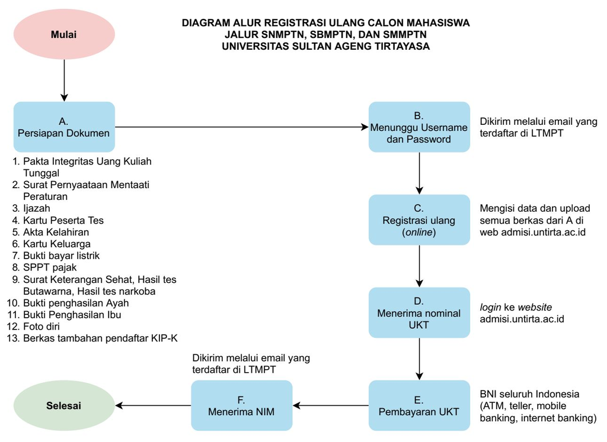

3. Penjelasan registrasi ulang secara *online* sesuai dengan jadwal dan diagram alur di atas adalah sebagai berikut.
   1. **Mempersiapkan dokumen** yang harus diunggah (*upload*) dalam bentuk **pdf** atau **jpg** (**ukuran file tidak melebihi 250 KB**).

      > Dokumen-dokumen yang harus disiapkan :
      1. [**Pakta Integritas Uang Kuliah Tunggal**](https://drive.google.com/file/d/1eFAlVSPMtTBDPZJXrbRC6ETnY1eU--F7/view?usp=sharing) (*download*, cetak, isi, *scan Asli*).
      2. [**Surat Pernyataan Mentaati Peraturan**](https://drive.google.com/file/d/1eDmL9tXhdXjfNSVceYwxh9a8gwuUcwYD/view?usp=sharing) (*download*, cetak, isi, *scan Asli*).
      3. [**Surat Keterangan Data Keluarga**](https://drive.google.com/file/d/1hEugzLMDnwLt2nkqwGfRx-o1AnVFxyvk/view?usp=sharing) (*download*, cetak, isi, *scan Asli*).
      4. Ijazah bagi lulusan 3 tahun terakhir : 2020, 2021, dan 2022 / Surat Keterangan Lulus (SKL) bagi lulusan tahun 2022 yang belum memperoleh Ijazah / Surat Keterangan Belum Ujian dari Sekolah bagi yang belum ujian. (Asli/Dilegalisir)

         > Bagi yang belum melakukan Ujian di Sekolahnya bisa menggunakan **Surat Keterangan Kelas XII** dari Sekolah.
      5. Kartu Peserta Tes (Asli)
      6. Akta Kelahiran (Asli/Dilegalisir)
      7. Kartu Keluarga (Asli/Dilegalisir)
      8. Bukti pembayaran listrik bagi pelanggang *pascabayar* **atau** bukti pembelian token listrik bagi pelanggan *prabayar* (Asli)

         Bagi pelanggan listrik 450VA yang digratiskan dan tidak memiliki bukti pembayaran bisa membuatnya di halaman [**https://stimulus.pln.co.id/**](https://stimulus.pln.co.id/) seperti pada gambar berikut.

[figure not shown]

      9. Bukti SPT Pajak Penghasilan Tahunan **bagi yang memiliki**, seperti contoh berikut. (Asli)

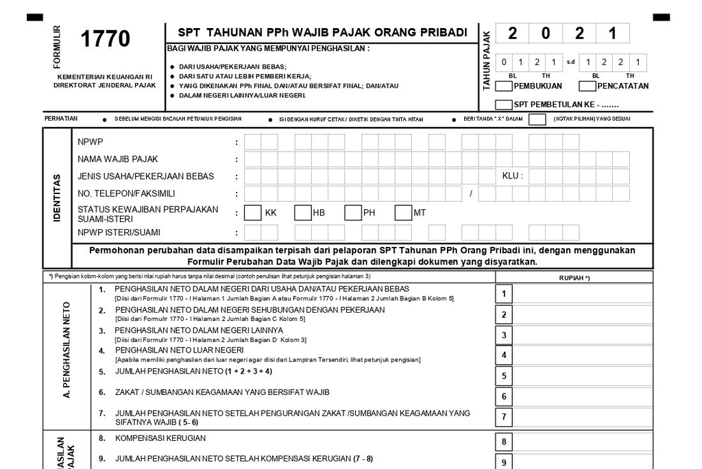

      10. Pilih salah satu yang paling sesuai.
          1. SPPT Pajak Bumi dan Bangunan (PBB) tiga tahun terakhir (pilih salah satu)
          2. [**Surat Pernyataan tentang Luas Tanah dan Bangunan Rumah yang ditempati**](https://drive.google.com/file/d/1eOsQ6Hk0Zk1y20Mxsy5ZP_0RVV5Am2N-/view?usp=sharing) bagi yang tidak punya SPPT (*download*, cetak, isi, *scan Asli*)
          3. Bukti pembayaran sewa rumah bagi yang mengontrak/sewa ditambah [**Surat Pernyataan tentang Luas Tanah dan Bangunan Rumah yang ditempati**](https://drive.google.com/file/d/1eO1EXEMdsA3sfW8XbeO8NxYMLZ1N9CQA/view?usp=sharing)(*download*, cetak, isi, *scan Asli*)
      11. Surat Tes Bebas Narkoba terbaru dari Rumah Sakit Pemerintah/BNN (*scan Asli* dan *upload*)
      12. Surat Keterangan Kesehatan dari Rumah Sakit/Klinik/Puskesmas (*scan Asli* dan *upload*)

          > **Surat Sehat, Buta Warna dan Narkoba harus yang terbaru atau pemeriksaan mulai tanggal 18 Juli - 27 Juli 2022**
      13. Surat Pemeriksaan Buta Warna dari Rumah Sakit/Klinik/Puskesmas untuk Program Studi berikut (*scan* dan *upload*) :

          | No. | Program Studi | Keterangan |
          | --- | --- | --- |
          | 1. | Pendidikan Biologi | Tidak Boleh Buta Warna |
          | 2. | Pendidikan Guru Sekolah Dasar | Tidak Boleh Buta Warna |
          | 3. | Pendidikan Guru Pendidikan Anak Usia Dini | Tidak Boleh Buta Warna |
          | 4. | Pendidikan Fisika | Tidak Boleh Buta Warna |
          | 5. | Pendidikan IPA | Tidak Boleh Buta Warna |
          | 6. | Pendidikan Kimia | Tidak Boleh Buta Warna |
          | 7. | Pendidikan Vokasional Teknik Mesin | Tidak Boleh Buta Warna |
          | 8. | Pendidikan Vokasional Teknik Elektro | Tidak Boleh Buta Warna |
          | 9. | Bimbingan dan Konseling | Tidak Boleh Buta Warna |
          | 10. | Pendidikan Pancasila dan Kewarganegaraan | Tidak Boleh Buta Warna |
          | 11. | Pendidikan Sejarah | Tidak Boleh Buta Warna |
          | 12. | Pendidikan Seni Pertunjukan | Tidak Boleh Buta Warna |
          | 13. | Teknik Mesin | Tidak Boleh Buta Warna |
          | 14. | Teknik Elektro | Tidak Boleh Buta Warna |
          | 15. | Teknik Industri | Buta Warna Sebagian / Partial masih boleh |
          | 16. | Teknik Metalurgi | Tidak Boleh Buta Warna |
          | 17. | Teknik Kimia | Tidak Boleh Buta Warna |
          | 18. | Teknik Sipil | Tidak Boleh Buta Warna |
          | 19. | Informatika | Tidak Boleh Buta Warna |
          | 20. | Kedokteran | Tidak Boleh Buta Warna |
          | 21. | Gizi | Tidak Boleh Buta Warna |
          | 22. | Ilmu Keolahragaan | Tidak Boleh Buta Warna |
          | 23. | Keperawatan (D3 & S1) | Tidak Boleh Buta Warna |

      > Isilah dengan **BENAR**, **AKURAT**, dan **JUJUR** semua data diri anda. Kesalahan dalam mengisi data dan memahami panduan registrasi menjadi tanggung jawab calon mahasiswa baru.

      > **Pertanyaan / Isian yang bertanda bintang (*) wajib di isi**, sedangkan untuk pertanyaan yang tidak ada tanda bintang bisa di isi jika anda mempunyai datanya atau boleh dikosongkan.

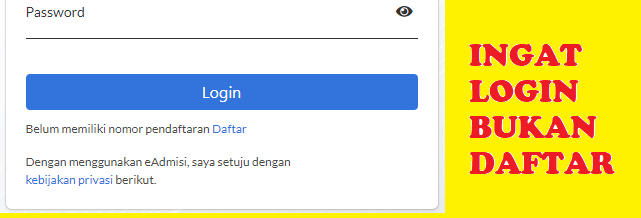

   2. **Menunggu Username dan Password** untuk login ke laman https://admisi.untirta.ac.id. yang akan dikirim oleh Panitia Registrasi ke email calon mahasiswa baru.

      > **Cek juga folder SPAM atau folder PROMOSI di email anda**, karena mungkin email dari kami masuk ke folder SPAM anda. Atau **search** email dengan judul **“Konfirmasi Pendaftaran”**.
   3. **Registrasi Ulang online** melakukan pengisian data diri dan mengunggah dokumen-dokumen yang diminta secara online di laman https://admisi.untirta.ac.id.

      > **Cetak Bukti Registrasi Online dan simpan** sebagai bukti jika dibutuhkan (tidak perlu tanda tangan petugas)
   4. **Menerima nominal UKT** yang bisa dilihat di [<https://admisi.untirta.ac.id>](https://admisi.untirta.ac.id) menggunakan akun *username* dan *password* masing-masing sesuai jadwal pembayaran.
   5. **Melakukan Pembayaran** Uang Kuliah Tunggal (UKT) di Bank BNI seluruh Cabang Indonesia melalui *Teller* atau ATM. Tata cara pembayaran UKT bisa diakses [**di sini**](https://drive.google.com/file/d/1IIaFh62Irl6cK4EpdaTqcwOk3OMfmH8t/view?usp=sharing).

      dengan ketentuan sebagai berikut.
      - Melakukan pembayaran Uang Kuliah Tunggal (UKT) dengan menyebut No Peserta Test.
      - Menerima bukti pembayaran dari Bank BNI (Teller atau ATM).
      - Khusus untuk Program Studi Kedokteran, UKT sebesar Rp15.000.000,00 s.d. Rp22.000.000,00 (UKT Kelompok III s.d. VIII)
   6. **Menerima Nomor Induk Mahasiswa (NIM)** dan *Password* SIAKAD akan dikirim melalui email masing-masing setelah Pembayaran terkonfirmasi Lunas.

      > NIM dan Password digunakan untuk melakukan proses kontrak matakuliah di laman https://siakad.untirta.ac.id/portal
      - **Pendaftar Non KIP-K**: setelah melakukan pembayaran UKT
      - **Pendaftar KIP-K**: setelah dinyatakan sebagai penerima KIP-K
   7. **Selesai,** Mahasiswa Baru selanjutnya menghubungi Fakultas dan Program Studi masing masing untuk **Kegiatan Belajar Mengajar (KBM)**
4. **Lain-lain**:
   1. Setiap calon mahasiswa yang **tidak dapat memenuhi ketentuan pengumuman ini dinyatakan mengundurkan diri** sebagai calon mahasiswa Universitas Sultan Ageng Tirtayasa.
   2. Semua biaya yang telah dibayarkan tidak bisa ditarik kembali.
   3. Jika ada pengumuman atau perubahan jadwal akan diberitahukan kemudian melalui
      1. https://admisi.untirta.ac.id,
      2. https://untirta.ac.id,
      3. https://registrasi.untirta.ac.id
      4. email anda masing-masing (**pastikan email anda aktif**).
   4. Hal yang belum jelas bisa ditanyakan melalui email **registrasi@untirta.ac.id** atau [**Hotline Registrasi : 0813-1173-4542**](http://wa.me/6281311734542)

> Jam Kantor Senin s.d. Jum’at (kecuali tanggal merah);

> Pelayanan Jam 08:00 - 15:00 Wib

> Istirahat Jam 12:00 - 13:00 Wib.